# Model Comparison Part II: Random Regressions

Hadasch, Schmidt, Piepho

2 Februar 2018

# General Information

- Dataset = aman
- Mod1:
  - $\begin{aligned} var(GL) &= \sigma_{GL}^2 \\ var(GY) &= \sigma_{GY}^2 \\ var(GYL) &= \sigma_{GYL}^2 + \sqrt{x_j}\sigma_{GYL}^2 + \sqrt{t_j}\sigma_{GYL}^2 \end{aligned}$
- Mod2:
  - $\begin{aligned} var(GL) &= \sigma_{GL}^2 \\ var(GY) &= \sigma_{GY}^2 \\ var(GYL) &= \sigma_{GYL}^2 + \sqrt{x_j}\sigma_{GYL}^2 + x_j \sigma_{GYL}^2 + \sqrt{t_j}\sigma_{GYL}^2 + t_j \sigma_{GYL}^2 \end{aligned}$
- Mod3:
  - $\begin{aligned} var(GL) &= \sigma_{GL}^2 + \sqrt{x_j}\sigma_{GL}^2 \\ var(GY) &= \sigma_{GY}^2 + \sqrt{x_j}\sigma_{GY}^2 + \sqrt{t_j}\sigma_{GY}^2 \\ var(GYL) &= \sigma_{GYL}^2 + \sqrt{x_j}\sigma_{GYL}^2 + \sqrt{t_j}\sigma_{GYL}^2 \end{aligned}$
- Mod4:
  - $\begin{aligned} var(GL) &= \sigma_{GL}^2 + \sqrt{x_j}\sigma_{GL}^2 + x_j \sigma_{GL}^2 \\ var(GY) &= \sigma_{GY}^2 + \sqrt{x_j}\sigma_{GY}^2 + x_j \sigma_{GY}^2 + \sqrt{t_j}\sigma_{GY}^2 + t_j \sigma_{GY}^2 \\ var(GYL) &= \sigma_{GYL}^2 + \sqrt{x_j}\sigma_{GYL}^2 + x_j \sigma_{GYL}^2 + \sqrt{t_j}\sigma_{GYL}^2 + t_j \sigma_{GYL}^2 \end{aligned}$
- Model Outputs (further formatting not shown):
  - AIC: `-2*MODELOBJECT$loglik + 2*length(MODELOBJECT$gammas)`
  - Wald test: `wald(MODELOBJECT, denDF = c("none"),ssType = c("incremental","conditional"))`
  - Variance Components: `summary(MODELOBJECT)$varcomp`
  - Residual Plot per $t_j$: `plot(dat3$tj,residuals(MODELOBJECT, type=("pearson")))`

### Create variables from xj and tj

```r
# "Centered" and squareroot
dat3$sc_xj <- sqrt(dat3$xj-min(dat3$xj))
dat3$sc_tj <- sqrt(dat3$tj-min(dat3$tj))
# "Centered"
dat3$c_xj   <- dat3$xj-min(dat3$xj)
dat3$c_tj   <- dat3$tj-min(dat3$tj)
```

## Model 1

```r
Mod1 <- asreml(fixed   = adjmean ~ xj + tj,
                 random  = ~ G + L + Y + G:L + G:Y +
                             G:Env +
                             sc_tj:G:Env +
                             sc_xj:G:Env,
                 ran.order = "user",
                 G.param = Gpar,
                 weights = w,
                 family  = asreml.gaussian(dispersion=1.0),
                 control = asreml.control(pworkspace=8e10,workspace=8e8,maxiter=100),
                 data    = dat3)
```

```
## [1] "AIC= 1966.85"
```

```
##                              component   std.error    constraint
## G!G.var                0.3036106131304 0.087031942      Positive
## L!L.var                0.2771514519169 0.140580131      Positive
## Y!Y.var                0.1064523392807 0.043837439      Positive
## G:L!G.var              0.0216993425869 0.009992365      Positive
## G:Y!G.var              0.0000001011929          NA      Boundary
## G:Env!G.var            0.9574640282449 0.063903390      Positive
## sc_tj:G:Env!sc_tj.var -0.0175324062835 0.006096273 Unconstrained
## sc_xj:G:Env!sc_xj.var -0.0046128609747 0.002141192 Unconstrained
## R!variance             1.0000000000000          NA         Fixed
```

```
##               Df Wald statistic Pr(Chisq)
## (Intercept)    1        313.874    <2e-16 ***
## xj             1          0.022    0.8822
## tj             1          0.500    0.4794
## residual (MS)
## ---
## Signif. codes:  0 '***' 0.001 '**' 0.01 '*' 0.05 '.' 0.1 ' ' 1
```

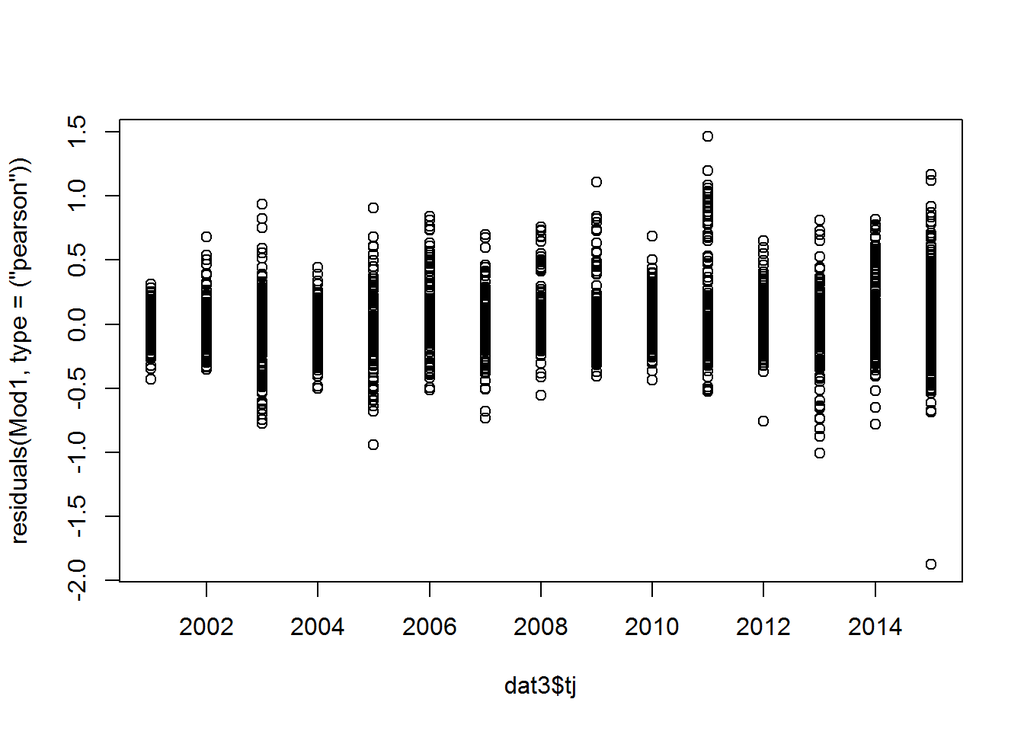

## Model 2

```r
Mod2 <- asreml(fixed   = adjmean ~ xj + tj,
                 random  = ~ G + L + Y + G:L + G:Y +
                                   G:Env +
                             sc_tj:G:Env + c_tj:G:Env +
                             sc_xj:G:Env + c_xj:G:Env,
                 ran.order = "user",
                 G.param = Gpar,
                 weights = w,
                 family  = asreml.gaussian(dispersion=1.0),
                 control = asreml.control(pworkspace=8e10,workspace=8e8,maxiter=100),
                 data    = dat3)
```

```
## [1] "AIC= 1970.31"
```

```
##                             component   std.error    constraint
## G!G.var                0.303673856393 0.087096485      Positive
## L!L.var                0.277300168059 0.140655109      Positive
## Y!Y.var                0.106397040293 0.043808432      Positive
## G:L!G.var              0.021490386364 0.009970680      Positive
## G:Y!G.var              0.000000100245          NA      Boundary
## G:Env!G.var            0.960009772899 0.108680814      Positive
## sc_tj:G:Env!sc_tj.var -0.006602648183 0.024279614 Unconstrained
## c_tj:G:Env!c_tj.var   -0.000722127708 0.001505406 Unconstrained
## sc_xj:G:Env!sc_xj.var -0.009106258722 0.007574864 Unconstrained
## c_xj:G:Env!c_xj.var    0.000113064301 0.000184463 Unconstrained
## R!variance             1.000000000000          NA         Fixed
```

```
##               Df Wald statistic Pr(Chisq)
## (Intercept)    1        313.917    <2e-16 ***
## xj             1          0.024    0.8776
## tj             1          0.482    0.4874
## residual (MS)
## ---
## Signif. codes:  0 '***' 0.001 '**' 0.01 '*' 0.05 '.' 0.1 ' ' 1
```

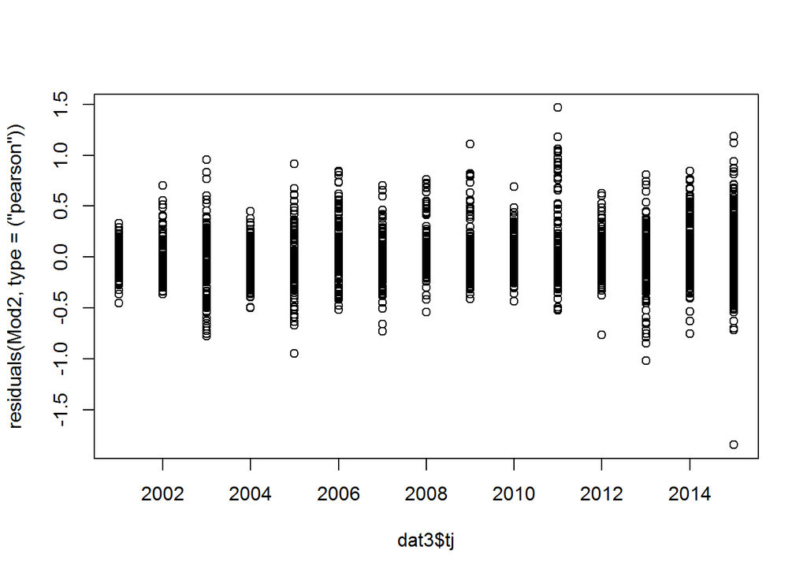

## Model 3

```r
Mod3 <- asreml(fixed   = adjmean ~ xj + tj,
                 random  = ~ G + L + Y +
                           G:L   + sc_xj:G:L   +
                           G:Y   + sc_xj:G:Y   + sc_tj:G:Y   +
                           G:Env + sc_xj:G:Env + sc_tj:G:Env,
                 ran.order = "user",
                 G.param = Gpar,
                 weights = w,
                 family  = asreml.gaussian(dispersion=1.0),
                 control = asreml.control(pworkspace=8e10,workspace=8e8,maxiter=100),
                 data    = dat3)
```

```
## [1] "AIC= 1956.04"
```

```
##                              component    std.error    constraint
## G!G.var                0.3127547588192 0.0882377154      Positive
## L!L.var                0.2736881845580 0.1388885407      Positive
## Y!Y.var                0.1085869643983 0.0442137282      Positive
## G:L!G.var              0.0069328362235 0.0194455897      Positive
## sc_xj:G:L!sc_xj.var    0.0006802965260 0.0009477873 Unconstrained
## G:Y!G.var              0.0000001011929           NA      Boundary
## sc_xj:G:Y!sc_xj.var   -0.0010297632637 0.0006634518 Unconstrained
## sc_tj:G:Y!sc_tj.var   -0.0006080311941 0.0017720226 Unconstrained
## G:Env!G.var            0.9279519973357 0.0634893568      Positive
## sc_xj:G:Env!sc_xj.var -0.0035677958531 0.0023542654 Unconstrained
## sc_tj:G:Env!sc_tj.var -0.0138724467469 0.0064189456 Unconstrained
## R!variance             1.0000000000000           NA         Fixed
```

```
##               Df Wald statistic Pr(Chisq)
## (Intercept)    1        314.182    <2e-16 ***
## xj             1          0.014    0.9066
## tj             1          0.439    0.5075
## residual (MS)
## ---
## Signif. codes:  0 '***' 0.001 '**' 0.01 '*' 0.05 '.' 0.1 ' ' 1
```

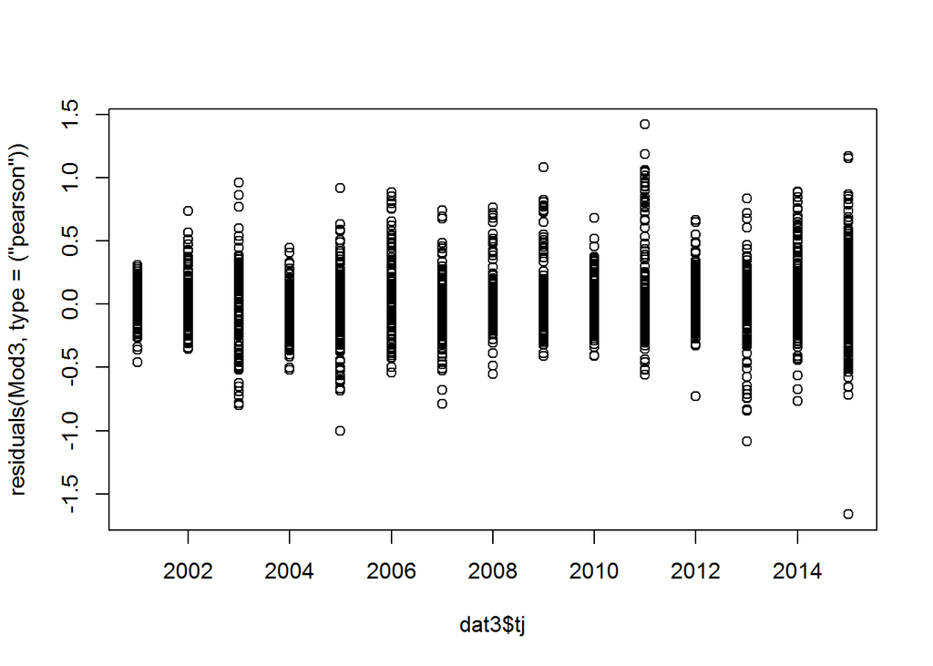

## Model 4

```r
Mod4 <- asreml(fixed   = adjmean ~ xj + tj,
                 random  = ~ G + L + Y +
                           G:L   + sc_xj:G:L   +
                                    c_xj:G:L   +
                           G:Y   + sc_xj:G:Y   + sc_tj:G:Y   +
                                    c_xj:G:Y   +  c_tj:G:Y   +
                           G:Env + sc_xj:G:Env + sc_tj:G:Env +
                                    c_xj:G:Env +  c_tj:G:Env,
                 ran.order = "user",
                 G.param = Gpar,
                 weights = w,
                 family  = asreml.gaussian(dispersion=1.0),
                 control = asreml.control(pworkspace=8e10,workspace=8e8,maxiter=100),
                 data    = dat3)
```

[output not shown]